# BMI Distribution

# 1 Introduction

# 2 Exploratory Analysis

Table 1 shows the Mean, Median and Standard deviation of the BMI results from 2013 - 2016. Looking at Table 1 Below, we can see that the mean and median values for the BMI have a slight increase from 2013 to 2016, which would suggest that there is a population-wide trend of increasing BMI values.

Table 1: Mean, Median and Standard deviation of the BMI from 2013-2016

| Year | Mean | Median | SD |
| --- | --- | --- | --- |
| 2013 | 27.81 | 27.08 | 5.28 |
| 2014 | 27.84 | 27.17 | 5.21 |
| 2015 | 28.02 | 27.26 | 5.53 |
| 2016 | 28.03 | 27.28 | 5.79 |

Figure 1 shows that despite the similar median and quartile values, there are notable differences in the spread and variability of the BMI results across the 4 years, with 2015 and 2016 having the most outliers. The presence of many outliers suggests that there is substantial variability and dispersion of BMI results for each year.

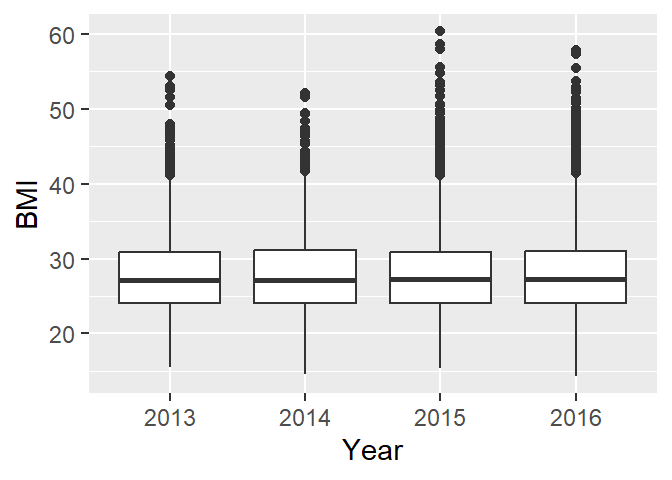

Figure 1: Boxplot for the BMI results for each year

Looking at Figure 2 below, we can see that it is slightly right skewed with the majority of the observations on the left-hand side of the histogram and a long tail extending towards the right. A right skewed histogram is also known as a positively skewed histogram and the peak of the graph can be found on the left-hand side and more specifically, between 20-30 BMI from the results.

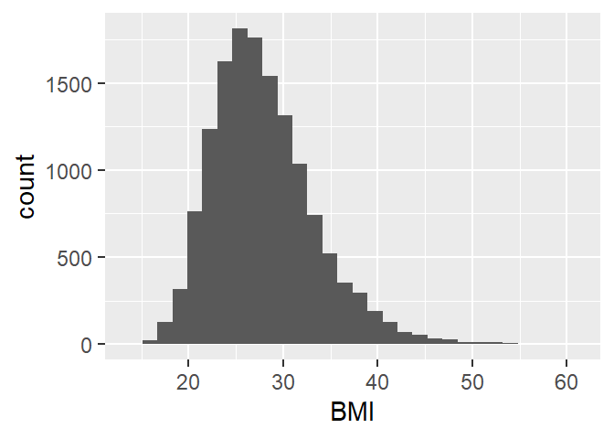

Figure 2: Histogram of the BMI results

Table 2 Shows the correlation between BMI and the other variables in the data. Here, we can see that all the correlation results are of very low correlation which suggests that the variables under consideration are not strongly related in a linear manner. Maybe looking at each year separately would show more accurate results and help find variables that are of stronger correlation.

Table 2: Correlation between BMI and other variables

| Variables | Correlation |
| --- | --- |
| Age | 0.14537 |
| Sex | 0.00512 |
| Education | −0.00150 |
| Veg | −0.00937 |
| Fruit | 0.02094 |

# 3 Formal Analysis

# 4 Conclusions